# A systematic review of short-term and working memory abilities in children with intellectual disability; to what extent do the result support the delay or difference hypotheses?

## Aim

The aim of the study is to investigate if short-term and working memory abilities exhibit a developmentally delayed or developmentally different pattern in children with ID. This will be done by an overall analysis and subgroup analyses based on type of memory (short-term or working memory), aetiology of ID (familial or organic). In addition, the overall analysis will also be repeated with level of IQ as a moderator.

### Research questions

1. Do short-term and working memory abilities exhibit a developmentally delayed or developmentally different pattern in children with ID (compared to mental age matched groups)? 1.1 Is this pattern moderated by origin of ID (familial and organic) or level of IQ?
2. Do origin (familial and organic) of ID or level of IQ moderate whether STM and WM performance are delayed or different?

### Hypotheses

1. The STM delay hypothesis will be supported if STM performance of participants with ID will not differ significantly from that of the mental age-matched group
2. The WM delay hypothesis will be supported if WM performance of participants with ID will not differ significantly from that of the mental age-matched group
3. The STM difference hypothesis will be supported if STM performance of participants with ID will differ significantly from that of the mental age-matched group. We expect that the difference may occur in any direction.
4. The WM difference hypothesis will be supported if WM performance of participants with ID will differ significantly from that of the mental age-matched group. We expect that the difference may occur in any direction.

## Methods

```r
head(data)
```

```
## # A tibble: 6 × 152
##   assigned_to authors     title  year type_of_publication country_of_data_coll…¹
##   <chr>       <chr>       <chr> <dbl> <chr>               <chr>
## 1 Lucija      Menghini     <NA>    NA journal article     Italy
## 2 Josefine    Menghini    "Exe…  2010 journal article     Italy
## 3 Henrik      Menghini     <NA>    NA journal article     Italy
## 4 Cris        Menghini e…  <NA>    NA Journal article     Italy
## 5 MT          Menghini e… "Exe…  2010 journal article     Italy
## 6 Lucija      Duarte       <NA>    NA journal article     Brazil
## # ℹ abbreviated name: ¹country_of_data_collection
## # ℹ 146 more variables: sample_size_id_n <dbl>, sample_size_id_source <chr>,
## #   sample_size_controls_n <dbl>, sample_size_controls_source <chr>,
## #   chronological_age_id_m <dbl>, chronological_age_id_sd <dbl>,
## #   chronological_age_id_range <chr>, chronological_age_id_source <chr>,
## #   chronological_age_controls_m <dbl>, chronological_age_controls_sd <dbl>,
## #   chronological_age_controls_range <chr>, …
```

```r
summary(data[, columns_of_interest])
```

```
##       year      sample_size_id_n chronological_age_id_m chronological_age_id_sd
##  Min.   :2010   Min.   :15.00    Min.   : 12.50         Min.   : 3.80
##  1st Qu.:2010   1st Qu.:15.00    1st Qu.: 91.07         1st Qu.:17.27
##  Median :2011   Median :25.00    Median :150.00         Median :17.27
##  Mean   :2012   Mean   :26.29    Mean   :143.23         Mean   :23.72
##  3rd Qu.:2014   3rd Qu.:37.75    3rd Qu.:229.32         3rd Qu.:45.60
##  Max.   :2017   Max.   :42.00    Max.   :239.00         Max.   :45.60
##  NA's   :7                                              NA's   :5
##  mental_age_id_m mental_age_id_sd    iq_id_m         iq_id_sd
##  Min.   : 6.80   Min.   : 2.40    Min.   :52.20   Min.   :5.4
##  1st Qu.:49.98   1st Qu.: 9.32    1st Qu.:53.30   1st Qu.:5.4
##  Median :73.20   Median : 9.32    Median :53.30   Median :5.4
##  Mean   :60.14   Mean   :14.28    Mean   :53.57   Mean   :5.4
##  3rd Qu.:81.60   3rd Qu.:28.80    3rd Qu.:54.20   3rd Qu.:5.4
##  Max.   :82.00   Max.   :28.80    Max.   :54.40   Max.   :5.4
##                  NA's   :5        NA's   :4       NA's   :9
##  sample_size_controls_n chronological_age_controls_m
##  Min.   :15.00          Min.   : 6.00
##  1st Qu.:15.00          1st Qu.:40.52
##  Median :25.00          Median :72.00
##  Mean   :27.08          Mean   :60.26
##  3rd Qu.:38.00          3rd Qu.:90.00
##  Max.   :50.00          Max.   :91.20
##  NA's   :1
##  chronological_age_controls_sd mental_age_controls_m mental_age_controls_sd
##  Min.   :0.050                 Min.   : 6.80         Min.   :0.700
##  1st Qu.:0.600                 1st Qu.:50.00         1st Qu.:5.880
##  Median :0.600                 Median :81.00         Median :5.880
##  Mean   :2.614                 Mean   :62.06         Mean   :5.569
##  3rd Qu.:5.250                 3rd Qu.:81.60         3rd Qu.:8.400
##  Max.   :5.880                 Max.   :82.80         Max.   :8.400
##  NA's   :5                                           NA's   :5
##  iq_controls_m   iq_controls_sd task_1_mean_control_group task_1_mean_id_group
##  Min.   : 95.7   Min.   :12.4   Min.   :4.800             Min.   :4.100
##  1st Qu.: 95.7   1st Qu.:12.4   1st Qu.:4.800             1st Qu.:4.100
##  Median :104.2   Median :12.4   Median :4.800             Median :4.100
##  Mean   :104.2   Mean   :12.4   Mean   :5.816             Mean   :4.833
##  3rd Qu.:112.8   3rd Qu.:12.4   3rd Qu.:7.160             3rd Qu.:5.810
##  Max.   :112.8   Max.   :12.4   Max.   :7.190             Max.   :5.810
##  NA's   :4       NA's   :9      NA's   :7                 NA's   :7
```

[output cut: 17 more lines]

```
##  Min.   :1               Min.   :1.1        Min.   :15
##  1st Qu.:1               1st Qu.:1.1        1st Qu.:15
##  Median :1               Median :1.1        Median :20
##  Mean   :1               Mean   :1.1        Mean   :20
##  3rd Qu.:1               3rd Qu.:1.1        3rd Qu.:25
##  Max.   :1               Max.   :1.1        Max.   :25
##  NA's   :10              NA's   :10         NA's   :8
##  task_2_n_id_group
##  Min.   :15.00
##  1st Qu.:15.00
##  Median :15.00
##  Mean   :18.33
##  3rd Qu.:22.50
##  Max.   :25.00
##  NA's   :8
```

Here are the plots for the first test

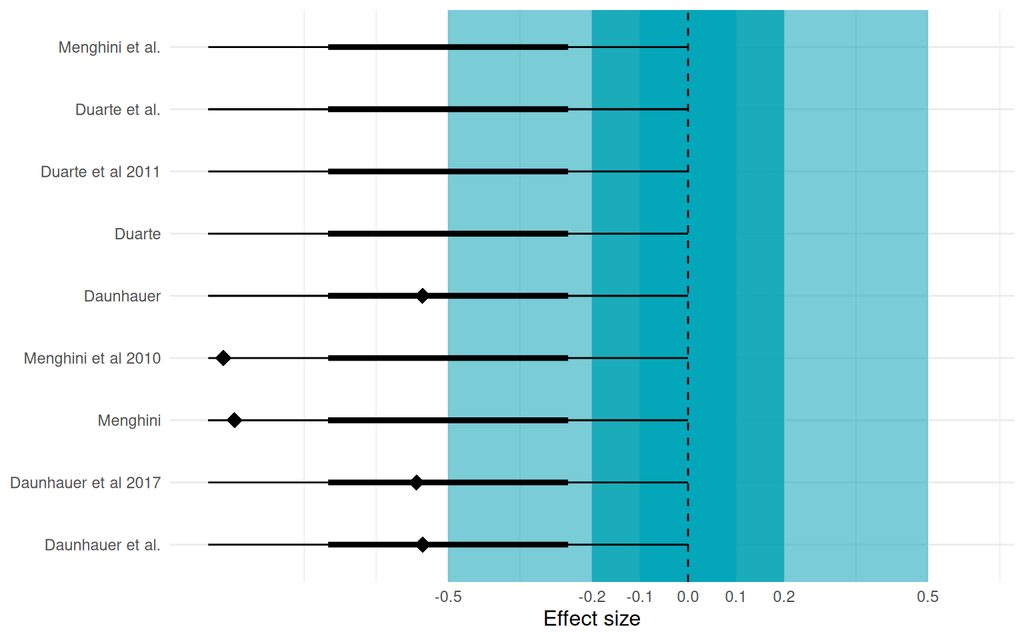

```r
combine_et(stats_test_1)
```

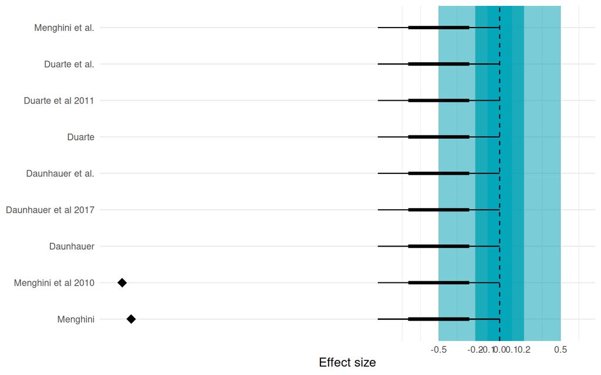

```r
combine_et(stats_test_2)
```